# STSCI 4630 - Lec 05

Harry Lu

Feburary 5, 2019

Aside on Maximum Likelihood Estimation (MLE)

Example:

Suppose $Y_1,\cdots,Y_n$ are observed binary variables, each having parameter $\theta$

$$f_{Y_i}(y_i;\theta)=P(Y_i=y_i;\theta)=\theta^{y_i}(1-\theta)^{1-y_i}\quad\text{where }y_i=0,1$$

By assuming independence

$$\begin{align}
f_{Y_1,\cdots,Y_n}(y_1,\cdots,y_n;\theta)
&=
\prod_{i=1}^{n}{P(Y_i=y_i;\theta)}\\
&=
\theta^{\sum_{i=1}^{n}{y_i}}(1-\theta)^{n-\sum_{i=1}^{n}{y_i}}
\end{align}$$

**Pearson: Method of Moments**

Let $Y=\sum_{i=1}^{n}Y_i$, so $Y \sim Bin(n,\theta)$

$$P(Y=y;\theta)=\left(\begin{array}{c}n\\y\end{array}\right)\theta^y(1-\theta)^{n-y}\quad\text{where }y=0,1,\cdots,n$$

$$\text{E}(Y)=n\theta$$

Equate $\frac{1}{n}\sum_{i=1}^{n}{Y_i}=\frac{1}{n}Y$ with its expectation and solve:

$$\text{E}\left(\frac{1}{n}Y\right)=\frac{1}{n}\cdot\text{E}(Y)=\frac{1}{n}\cdot n\theta=\theta$$

MOM: $\tilde\theta=\frac{1}{n}Y=\bar{Y}$

**Fisher: MLE**

Estimate $\theta$ by the value that maximized the probability of the observed data

Suppose we observe $Y_1=y_1,\cdots,Y_n=y_n$

Likelihood Function:

$$\begin{align}
\mathcal{L}(\theta;y_1,\cdots,y_n)
&=
P(Y_1=y_1,\cdots,Y_n=y_n;\theta)\\
&=
\theta^{\sum_{i=1}^{n}{y_i}}(1-\theta)^{n-\sum_{i=1}^{n}{y_i}}\\
&=
\theta^y(1-\theta)^{n-y}\quad\text{where }y=\sum_{i=1}^{n}{y_i}
\end{align}$$

Log Likelihood Function:

$$\mathcal{l}(\theta;y_1,\cdots,y_n)=y\cdot\ln(\theta)+(n-y)\cdot\ln (1-\theta)$$

Score Function:

$$\frac{\partial\mathcal{l}(\theta)}{\partial\theta}=\mathcal{l}'(\theta)=\frac{y}{\theta}-\frac{n-y}{1-\theta}$$

Set $\mathcal{l}'(\hat\theta)=0$, and we get $\hat\theta=\frac{1}{n}y$

MLE: $\hat\theta=\frac{1}{n}y$

Information concepts:

$$\frac{\partial^2\mathcal{l}(\theta)}{\partial\theta^2}=\mathcal{l}''(\theta)=-\frac{y}{\theta^2}-\frac{n-y}{(1-\theta)^2}$$

Expected Information:

$$\begin{align}
\mathcal{I}(\theta)
&=
\text{E}\left[-l''(\theta)\right]\\
&=
\text{E}\left[\frac{y}{\theta^2}+\frac{n-y}{(1-\theta)^2}\right]\\
&=
\frac{n\theta}{\theta^2}+\frac{n(1-\theta)}{(1-\theta)^2}\\
&=
\frac{n}{\theta(1-\theta)}
\end{align}$$

Note: $\text{Var}(Y)=n\theta(1-\theta)$

$\text{Var}(\hat\theta)=\text{Var}(\frac{1}{n}Y)=\frac{1}{n^2}\text{Var}(Y)=\frac{\theta(1-\theta)}{n}$

Here: $\text{Var}(\hat\theta)=\frac{1}{\mathcal{I}(\theta)}$

What can be said in general?

Suppose $\breve\theta$ is an unbiased estimate of $\theta$

i.e. $\text{E}(\breve\theta)=\theta$

**Cramer-Rao Lower Bound:**

$$\text{Var}(\breve\theta)\geq\frac{1}{\mathcal{I}(\theta)}$$

$$\sqrt{\mathcal{I}(\theta)}\cdot(\hat\theta-\theta)=\frac{\hat\theta-\theta}{\sqrt{\frac{1}{\mathcal{I}(\theta)}}} \xrightarrow{d} N(0,1)\text{ as }n\rightarrow\infty$$

But for example, $\frac{\hat\theta-\theta}{\sqrt{\frac{1}{\mathcal{I}(\theta)}}} \sim N(0,1)$ is useless for inference. Estimate $\text{sd}(\hat\theta)=\sqrt{\frac{\theta(1-\theta)}{n}}$ by $\text{SE}(\hat\theta)=\sqrt{\frac{\hat\theta(1-\hat\theta)}{n}}$ use $\frac{\hat\theta-\theta}{\sqrt{\frac{\hat\theta(1-\hat\theta)}{n}}}=\frac{\hat\theta-\theta}{\text{SE}(\hat\theta)}\approx N(0,1)$

$$P\left(-Z_{\frac{\alpha}{2}}\leq\frac{\hat\theta-\theta}{\sqrt{\frac{\theta(1-\theta)}{n}}}\leq Z_{\frac{\alpha}{2}}\right)\approx 1-\alpha$$

Approx $100(1-\alpha)\%$ confidence interval:

$$\left\{\theta\left|-Z_{\frac{\alpha}{2}}\leq\frac{\hat\theta-\theta}{\sqrt{\frac{\theta(1-\theta)}{n}}}\leq Z_{\frac{\alpha}{2}}\right.\right\}$$

$$P\left(-Z_{\frac{\alpha}{2}}\leq\frac{\hat\theta-\theta}{\sqrt{\frac{\hat\theta(1-\hat\theta)}{n}}}\leq Z_{\frac{\alpha}{2}}\right)\approx 1-\alpha$$

Approx $100(1-\alpha)\%$ confidence interval:

$$\hat\theta\pm Z_{\frac{\alpha}{2}}\sqrt{\frac{\hat\theta(1-\hat\theta)}{n}}=\hat\theta\pm Z_{\frac{\alpha}{2}}\cdot\text{SE}(\hat\theta)$$

In general: $\frac{\mathcal{I}(\hat\theta)}{\mathcal{I}(\theta)}\xrightarrow{p}1$

By Slutsky’s Theorem: $\sqrt{\mathcal{I}(\hat\theta)}\cdot(\hat\theta-\theta)\xrightarrow{d}N(0,1)$ since the limiting distribution of $\sqrt{\mathcal{I}(\hat\theta)}\cdot(\hat\theta-\theta)$ is the same as that of $\underbrace{\sqrt{\mathcal{I}(\theta)}\cdot(\hat\theta-\theta)}_{\begin{array}{c}\,\,\downarrow{d}\\N(0,1)\end{array}}\cdot\underbrace{\sqrt{\frac{\mathcal{I}(\hat\theta)}{\mathcal{I}(\theta)}}}_{\begin{array}{c}\,\,\downarrow{p}\\1\end{array}}$

Call $\text{SE}(\hat\theta)=\frac{1}{\sqrt{\mathcal{I}(\hat\theta)}}$

$$\frac{\hat\theta-\theta}{\text{SE}(\hat\theta)} \sim N(0,1)$$

Approx $100(1-\alpha)\%$ confidence interval:

$$\hat\theta\pm Z_{\frac{\alpha}{2}}\cdot\text{SE}(\hat\theta)$$

$H_0:\theta=\theta_0$, then $Z=\frac{\hat\theta-\theta_0}{\text{SE}(\hat\theta)}$ test statistic use $N(0,1)$ distribution for $p$ - value

$H_{a_1}:\theta>\theta_0$, $p$ - value is right tail

$H_{a_2}:\theta<\theta_0$, $p$ - value is left tail

$H_{a_3}:\theta\neq\theta_0$, $p$ - value is both tails

Recall $\mathcal{I}(\theta)=\text{E}[-l''(\theta)]$

What if the expectation is hard to do? We observed information!

Estimate $\text{E}[-l''(\theta)]$ by $-l''(\theta)$, so we estimate $\mathcal{I}(\hat\theta)$ by $-l''(\hat\theta)$, hence use $\text{SE}(\hat\theta)=\frac{1}{\sqrt{-l''(\hat\theta)}}$

Why the term information?

When $-l''(\hat\theta)$ is large:

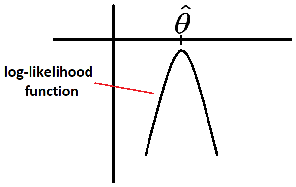

When $-l''(\hat\theta)$ is small:

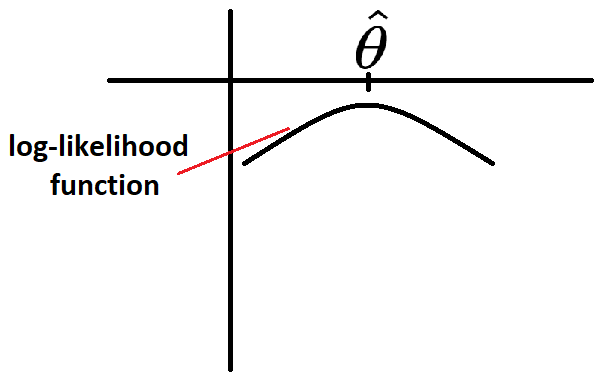

Consider now $Y_1,\cdots,Y_n$ are independent $N(\mu,\sigma^2)$

$$f_{Y_i}\left(y_i;\mu,\sigma^2\right)=\frac{1}{\sigma\sqrt{2\pi}}e^{-\frac{1}{2}\left(\frac{y_i-\mu}{\sigma}\right)^2}$$

$$\begin{align}
f_{Y_1,\cdots,Y_n}\left(y_1,\cdots,y_n;\mu,\sigma^2\right)
&=
\prod_{i=1}^{n}{f_{Y_i}\left(y_i;\mu,\sigma^2\right)}\\
&=
\frac{1}{\sigma^n(2\pi)^{\frac{n}{2}}}e^{-\frac{1}{2\sigma^2}\sum_{i=1}^{n}(y_i-\mu)^2}
\end{align}$$

$$Y_i=y_i\leftrightarrow Y_i\in(y_i-\triangle,y_i+\triangle)$$

Thanks to *Wanxin Lyu* for help with the notes.